# PEC 2

Laia Giralt

28/5/2020

# 1. Abstract

# 2. Introducció

En aquest estudi analitzarem dades de mostres del projecte Genotip-Tissue Expression (GTEx). En aquest projecte hi ha mostres de 54 teixit de 1000 individus. en el nostre anàlisis ens centrarem en aquelles mostres de tiroides i en les dades de RNA-seq, és a dir en les dades de la seva expressió. Aquestes mostres estan dividides en tres grups: - Not infiltrated tissues (NIT) - Small focal infiltrates (SFI) - Extensive lymphoid infiltrates (ELI)

# 3. Objectius

- Comparar l’expressió gènica dels diferents grups de mostres de teixits de tiroides
- Identificar gens diferencialment expressats entre els tres grups d’estudi: NIT, SFI i ELI
- Analitzar la significació biològica dels resultats

# 4. Materials i mètodes

Aquest estudi s’ha aplicat en un dataset del projecte Genotip-Tissue Expression (GTEx) on hi havia les dades de diferents mostres de tiroides que es troben classificades en 3 grups: - Not infiltrated tissues (NIT) - Small focal infiltrates (SFI) - Extensive lymphoid infiltrates (ELI)

Els anàlisis bioinformàtics s’han realitzat amb el codi de R, amb el programari de Rstudio i algunes llibreries de Bioconductor (www.bioconductior.org). Algunes de les llibreries que hem utilitzat són:

- library(oligo)
- library(Biobase)
- library(pd.hta.2.0)
- library(RSQLite)
- library(DBI)
- library(readr)
- library(DESeq)

```r
library(oligo)
library(Biobase)
library(pd.hta.2.0)
library(RSQLite)
library(DBI)
library(readr)
library(DESeq)
```

## 4.1 Preparació de dades

Ens hem descarregat l’arxiu que ens han facilitat per realitzar la PEC on hi havia totes les dades de les diverses mostres. En primer lloc hem modificat aquesta taula per adequar els noms de les mostres a la codificació de ENSEMBL que necessitarem a posteriori. Per fer-ho, hem utilitzat l’eina de buscar i reemplaçar del mateix “EXCEL”. Un cop hem accedit a la eina a través del menú, he col·locat la següent cerca: .** Això vol dir que ens busqui tots els punts que hi hagi i els dos elements posteriors sense tenir en compte què són. A continuació posem que es reemplaci, d’aquesta manera borrem el punt i els números que hi ha a darrera.

Un cop realitzada aquesta modificació, hem continuat el nostre procés amb RStudio, on el primer que farem és carregar la nostra base de dades.

```r
celFiles = read_delim("./counts.csv",";", escape_double = FALSE, trim_ws = TRUE)
```

Després carregarem una segona taula, que també ens han subministrat, on hi ha diversa informació de les nostres mostres. Entre aquesta informació hi ha el grup en què pertany cada mostra. Per fer-ho utilitzem el següent codi:

```r
targets = read_delim("./targets.csv",",", escape_double = FALSE, trim_ws = TRUE)
```

### 4.1.1 Selecció de dades

Tal i com ens demana l’investigador (l’enunciat de la PEC2), seleccionem 10 valors de cada grup. En el nostre cas el què fem és ordenar les mostres segons el grup d’anàlisis i seleccionem les 10 primeres de cada grup. Aquestes 10 mostres les guardem en una nova variable. Quan tenim les 3 noves variables (una de cada grup), les tornem a unir en una nova taula anomenada targets1. Tot això ho fem gràcies el següent codi:

```r
#Seleccionem els 10 primers valors de cada grup
data1= targets[targets$Grupo_analisis==1,][1:10,]
data2=targets[targets$Grupo_analisis==2,][1:10,]
data3=targets[targets$Grupo_analisis==3,][1:10,]

#Unim totes les taules
targets1= rbind(data1, data2, data3)
```

Tot seguit, passarem els Grups d’anàlisis de la nova taula targets1 a factors amb el següent codi:

```r
targets1$Grupo_analisis <- factor(targets1$Grupo_analisis, labels=c("NIT", "SFI","ELI"))
```

En aquest punt, utilitzarem la variable Sample_Name de la taula targets1 per poder seleccionar les columnes de la taula celFiles(on hi ha les dades concretes d’expressió de les nostres mostres) que ens interessen (les 30 mostres que hem seleccionat amb passos anteriors). Per fer-ho utilitzarem el següent codi:

```r
noms= targets1$Sample_Name
countTable = celFiles[ ,noms ]
```

## 4.2. Normalització

S’ha realitzat la normalització de les dades per fer que les mostres siguin comparables entre elles. D’aquesta manera s’intenta reduir, i si es pot eliminar, tot la variabilitat que no sigui deguda a raons biològiques, com podrien ser biaxos per problemes tècnics.

Com que treballarem amb el paquet DESeq, hem de començar l’anàlisi amb la funció newCountDataSet(). Per poder-la utilitzar necessitem la matriu de contejos bruts (en el nostre cas és la celFile) i una variable amb les condicions, que en el nostre cas són els diferents grups on pertanyen les mostres (NIT, SFI i ELI). Per realitzar-ho creem una nova variable on guardem els diferents grups on pertanyen les mostres. utilitzem el següent codi:

```r
condition = targets1$Grupo_analisis
cds = newCountDataSet(countTable, condition )
```

A continuació, hem de calcular els factors de normalització per convertir els contejos en comparables entre els grups. Per fer això, utilitzem la funció estimateSizeFactors per crear una proporció de contejos que rep cada mostra o individu:

```r
cds = estimateSizeFactors( cds )
sizeFactors( cds )
```

Amb aquests factors de normalització i utilitzant la funció counts() amb l’atribut normalized=TRUE, podem obtenir els nostres contejos normalitzats

```r
head(counts( cds, normalized=TRUE ) )
```

```
##   GTEX-111CU-0226-SM-5GZXC GTEX-111FC-1026-SM-5GZX1 GTEX-111YS-0726-SM-5GZY8
## 1                  5.92893                0.0000000                 4.186753
## 2                339.64298              892.8391120               413.441847
## 3                  3.38796                0.0000000                 2.093376
## 4                  1.69398                0.0000000                 1.046688
## 5                  0.00000                0.0000000                 0.000000
## 6                  0.00000                0.8391345                 1.046688
##   GTEX-1122O-0226-SM-5N9DA GTEX-1128S-0126-SM-5H12S GTEX-113JC-0126-SM-5EGJW
## 1                 2.092922                 2.035486                 0.000000
## 2               766.009426               642.195811               377.161603
## 3                 1.046461                 0.000000                 1.139461
## 4                 1.046461                 0.000000                 0.000000
## 5                 0.000000                 0.000000                 0.000000
## 6                 0.000000                 0.000000                 2.278922
##   GTEX-117XS-0526-SM-5987Q GTEX-117YX-1226-SM-5H11S GTEX-1192W-0126-SM-5EGGS
```

[output cut: 55 more lines]

```r
if (!requireNamespace("BiocManager", quietly = TRUE))
    install.packages("BiocManager")

BiocManager::install("oligo")
BiocManager::install("pd.hta.2.0")
library(oligo)
library(Biobase)
library(pd.hta.2.0)
library(RSQLite)
library(DBI)
library(readr)
targets = read_delim("./targets.csv",",", escape_double = FALSE, trim_ws = TRUE)
celFiles = read_delim("./counts.csv",";", escape_double = FALSE, trim_ws = TRUE)
if (!requireNamespace("BiocManager", quietly = TRUE))
    install.packages("BiocManager")

BiocManager::install("SummarizedExperiment")
if (!requireNamespace("BiocManager", quietly = TRUE))
    install.packages("BiocManager")

BiocManager::install("DESeq")
```

Seleccionar dades

```r
library(DESeq)
#Seleccionem els 10 primers valors de cada grup
data1= targets[targets$Grupo_analisis==1,][1:10,]
data2=targets[targets$Grupo_analisis==2,][1:10,]
data3=targets[targets$Grupo_analisis==3,][1:10,]

#Unim totes les taules
targets1= rbind(data1, data2, data3)
targets1$Grupo_analisis <- factor(targets1$Grupo_analisis, labels=c("NIT", "SFI","ELI"))

noms= targets1$Sample_Name
countTable = celFiles[ ,noms ]

condition = targets1$Grupo_analisis
```

8.2 Normalització

```r
cds = newCountDataSet(countTable, condition )

cds = estimateSizeFactors( cds )
sizeFactors( cds )
```

```
## GTEX-111CU-0226-SM-5GZXC GTEX-111FC-1026-SM-5GZX1 GTEX-111YS-0726-SM-5GZY8
##                1.1806515                1.1917041                0.9553943
## GTEX-1122O-0226-SM-5N9DA GTEX-1128S-0126-SM-5H12S GTEX-113JC-0126-SM-5EGJW
##                0.9556018                0.9825664                0.8776079
## GTEX-117XS-0526-SM-5987Q GTEX-117YX-1226-SM-5H11S GTEX-1192W-0126-SM-5EGGS
##                0.8568769                1.0367712                0.9659156
## GTEX-1192X-1126-SM-5EGGU GTEX-117YW-0126-SM-5EGGN GTEX-11DXY-0426-SM-5H12R
##                0.9001327                0.7706909                1.0824258
## GTEX-11EQ8-0826-SM-5N9FG GTEX-11EQ9-0626-SM-5A5K1 GTEX-11GS4-0826-SM-5986J
##                1.1730163                1.3725686                1.0197845
## GTEX-11O72-2326-SM-5BC7H GTEX-11TUW-0226-SM-5LU8X GTEX-1211K-0726-SM-5FQUW
##                1.1929657                0.8913330                0.9621979
## GTEX-12584-0826-SM-5FQSK GTEX-12BJ1-0426-SM-5FQSO GTEX-111VG-0526-SM-5N9BW
##                1.0826486                0.9792067                1.0093584
## GTEX-11NV4-0626-SM-5N9BR GTEX-11XUK-0226-SM-5EQLW GTEX-13NZ9-1126-SM-5MR37
##                1.1606740                1.0042035                1.4377516
## GTEX-13QJC-0826-SM-5RQKC GTEX-14ABY-0926-SM-5Q5DY GTEX-14AS3-0226-SM-5Q5B6
##                1.0016299                1.3320711                0.9575846
## GTEX-14BMU-0226-SM-5S2QA  GTEX-PLZ4-1226-SM-2I5FE  GTEX-R55G-0726-SM-2TC6J
##                0.8995892                1.3490857                0.3285140
```

```r
cds
```

```
## CountDataSet (storageMode: environment)
## assayData: 56202 features, 30 samples
##   element names: counts
## protocolData: none
## phenoData
##   sampleNames: GTEX-111CU-0226-SM-5GZXC GTEX-111FC-1026-SM-5GZX1 ...
##     GTEX-R55G-0726-SM-2TC6J (30 total)
##   varLabels: sizeFactor condition
##   varMetadata: labelDescription
## featureData: none
## experimentData: use 'experimentData(object)'
## Annotation:
```

```r
head(counts( cds, normalized=TRUE ) )
```

```
##   GTEX-111CU-0226-SM-5GZXC GTEX-111FC-1026-SM-5GZX1 GTEX-111YS-0726-SM-5GZY8
## 1                  5.92893                0.0000000                 4.186753
## 2                339.64298              892.8391120               413.441847
## 3                  3.38796                0.0000000                 2.093376
## 4                  1.69398                0.0000000                 1.046688
## 5                  0.00000                0.0000000                 0.000000
## 6                  0.00000                0.8391345                 1.046688
##   GTEX-1122O-0226-SM-5N9DA GTEX-1128S-0126-SM-5H12S GTEX-113JC-0126-SM-5EGJW
## 1                 2.092922                 2.035486                 0.000000
## 2               766.009426               642.195811               377.161603
## 3                 1.046461                 0.000000                 1.139461
## 4                 1.046461                 0.000000                 0.000000
## 5                 0.000000                 0.000000                 0.000000
## 6                 0.000000                 0.000000                 2.278922
##   GTEX-117XS-0526-SM-5987Q GTEX-117YX-1226-SM-5H11S GTEX-1192W-0126-SM-5EGGS
```

[output cut: 55 more lines]

Estimació de la variança

```r
cds = estimateDispersions( cds )
str( fitInfo(cds) )
```

```
## List of 5
##  $ perGeneDispEsts: num [1:56202] 0.6334 0.1111 -0.0692 1.2568 0.7149 ...
##  $ dispFunc       :function (q)
##   ..- attr(*, "coefficients")= Named num [1:2] 0.363 1.08
##   .. ..- attr(*, "names")= chr [1:2] "asymptDisp" "extraPois"
##   ..- attr(*, "fitType")= chr "parametric"
##  $ fittedDispEsts : num [1:56202] 0.89 0.364 1.303 1.516 2.794 ...
##  $ df             : int 27
##  $ sharingMode    : chr "maximum"
```

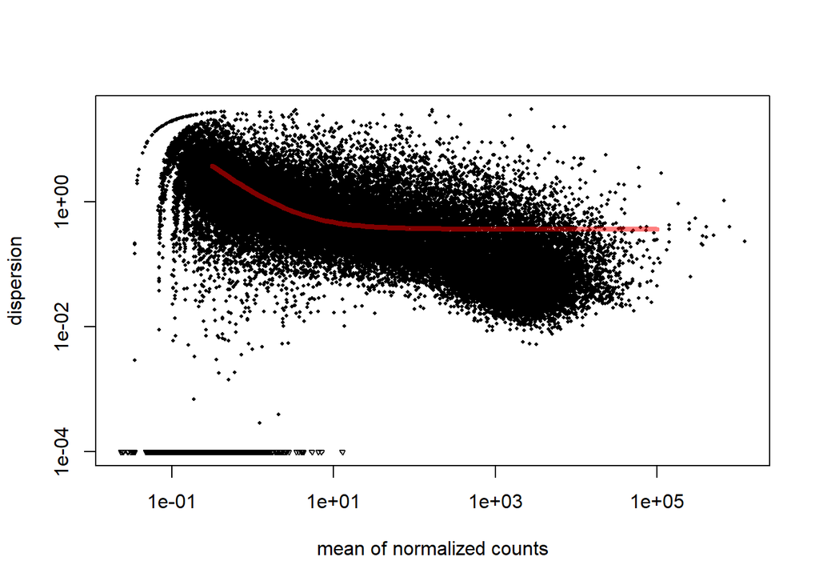

```r
plotDispEsts( cds )
```

## Interferencia: observar la diferenciació d’expressió

### Comparació entre dos condicions experimenals

#### NIT-SFI

```r
res = nbinomTest( cds, "NIT", "SFI" )
head(res)
```

```
##   id    baseMean   baseMeanA   baseMeanB foldChange log2FoldChange      pval
## 1  1   2.1019178   2.5966532   1.6071824  0.6189438    -0.69211967 0.4118210
## 2  2 593.5008372 587.9878457 599.0138286  1.0187521     0.02680298 0.9663925
## 3  3   1.2277668   1.3202416   1.1352919  0.8599122    -0.21773870 1.0000000
## 4  4   0.8858846   1.0530724   0.7186967  0.6824760    -0.55114978 0.8175424
## 5  5   0.2789310   0.1110947   0.4467673  4.0214984     2.00773313 0.4028064
## 6  6   0.9590124   0.8437635   1.0742613  1.2731782     0.34843440 0.7503764
##   padj
## 1    1
## 2    1
## 3    1
## 4    1
## 5    1
## 6    1
```

```r
res$id=celFiles$X1

head(res)
```

```
##                id    baseMean   baseMeanA   baseMeanB foldChange log2FoldChange
## 1 ENSG00000223972   2.1019178   2.5966532   1.6071824  0.6189438    -0.69211967
## 2 ENSG00000227232 593.5008372 587.9878457 599.0138286  1.0187521     0.02680298
## 3 ENSG00000243485   1.2277668   1.3202416   1.1352919  0.8599122    -0.21773870
## 4 ENSG00000237613   0.8858846   1.0530724   0.7186967  0.6824760    -0.55114978
## 5 ENSG00000268020   0.2789310   0.1110947   0.4467673  4.0214984     2.00773313
## 6 ENSG00000240361   0.9590124   0.8437635   1.0742613  1.2731782     0.34843440
##        pval padj
## 1 0.4118210    1
## 2 0.9663925    1
## 3 1.0000000    1
## 4 0.8175424    1
## 5 0.4028064    1
## 6 0.7503764    1
```

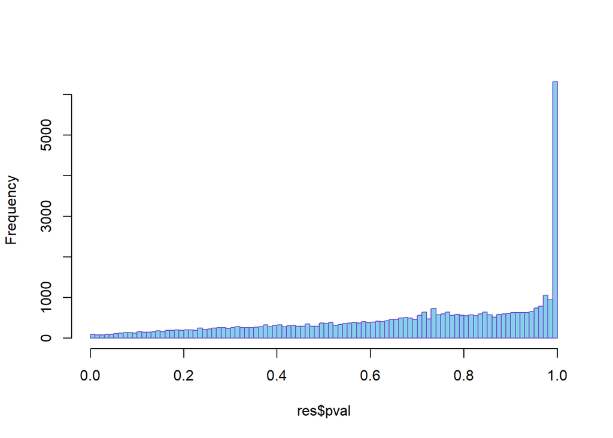

```r
hist(res$pval, breaks=100, col="skyblue", border="slateblue", main="")
```

```r
resSig = res[ res$pval < 0.1, ]
head( resSig[ order(resSig$pval), ] )
```

```
##                    id  baseMean  baseMeanA  baseMeanB foldChange log2FoldChange
## 6725  ENSG00000244116 54.773917  7.7290159 101.818817   13.17358       3.719576
## 12867 ENSG00000188848 27.506450  2.1099999  52.902900   25.07247       4.648032
## 45287 ENSG00000244649  2.504025  0.0000000   5.008049        Inf            Inf
## 52473 ENSG00000211685 32.857579  3.4685437  62.246614   17.94604       4.165593
## 3379  ENSG00000143297 77.216724 12.8616299 141.571818   11.00730       3.460389
## 6764  ENSG00000241244  6.553354  0.1017743  13.004934  127.78210       6.997542
##               pval      padj
## 6725  4.458933e-06 0.1963001
## 12867 1.213442e-04 1.0000000
## 45287 1.300015e-04 1.0000000
## 52473 1.682389e-04 1.0000000
## 3379  1.876961e-04 1.0000000
## 6764  2.266815e-04 1.0000000
```

#### SFI-ELI

```r
res_SFI_ELI = nbinomTest( cds, "SFI", "ELI" )
head(res_SFI_ELI)
```

```
##   id    baseMean   baseMeanA   baseMeanB foldChange log2FoldChange      pval
## 1  1   1.7729725   1.6071824   1.9387626  1.2063115     0.27060251 0.9275800
## 2  2 610.5895473 599.0138286 622.1652659  1.0386493     0.05470855 0.8143045
## 3  3   1.0615044   1.1352919   0.9877169  0.8700114    -0.20089384 0.6996683
## 4  4   0.8769412   0.7186967   1.0351857  1.4403653     0.52643474 1.0000000
## 5  5   0.6104067   0.4467673   0.7740461  1.7325489     0.79289606 0.9874085
## 6  6   0.8070837   1.0742613   0.5399061  0.5025836    -0.99256452 0.4747199
##   padj
## 1    1
## 2    1
## 3    1
## 4    1
## 5    1
## 6    1
```

```r
res_SFI_ELI$id=celFiles$X1

head(res_SFI_ELI)
```

```
##                id    baseMean   baseMeanA   baseMeanB foldChange log2FoldChange
## 1 ENSG00000223972   1.7729725   1.6071824   1.9387626  1.2063115     0.27060251
## 2 ENSG00000227232 610.5895473 599.0138286 622.1652659  1.0386493     0.05470855
## 3 ENSG00000243485   1.0615044   1.1352919   0.9877169  0.8700114    -0.20089384
## 4 ENSG00000237613   0.8769412   0.7186967   1.0351857  1.4403653     0.52643474
## 5 ENSG00000268020   0.6104067   0.4467673   0.7740461  1.7325489     0.79289606
## 6 ENSG00000240361   0.8070837   1.0742613   0.5399061  0.5025836    -0.99256452
##        pval padj
## 1 0.9275800    1
## 2 0.8143045    1
## 3 0.6996683    1
## 4 1.0000000    1
## 5 0.9874085    1
## 6 0.4747199    1
```

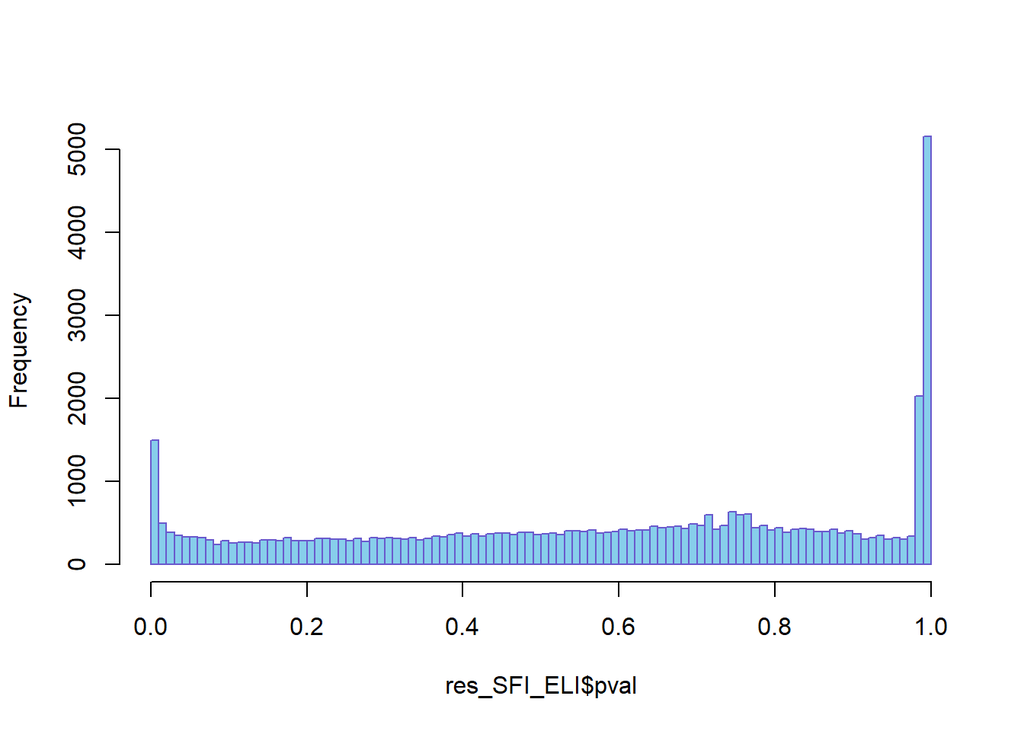

```r
hist(res_SFI_ELI$pval, breaks=100, col="skyblue", border="slateblue", main="")
```

```r
resSig_SFI_ELI = res_SFI_ELI[ res$pval < 0.1, ]
head( resSig_SFI_ELI [ order(resSig_SFI_ELI $pval), ] )
```

```
##                    id   baseMean  baseMeanA  baseMeanB foldChange
## 14291 ENSG00000243417  10.386358  1.1054872  19.667228  17.790553
## 17963 ENSG00000263391   4.322647  0.4894654   8.155828  16.662724
## 44046 ENSG00000240505 192.763187  6.9269578 378.599416  54.655944
## 50106 ENSG00000089012 261.818465 34.6608739 488.976056  14.107436
## 17136 ENSG00000172568   7.352266  1.8384813  12.866052   6.998195
## 26479 ENSG00000225411   7.351770  0.5408776  14.162662  26.184598
##       log2FoldChange         pval         padj
## 14291       4.153039 1.965107e-10 8.767716e-06
## 17963       4.058552 1.383732e-06 6.173798e-03
## 44046       5.772307 2.763901e-06 7.591720e-03
## 50106       3.818384 4.045306e-06 7.591720e-03
## 17136       2.806983 4.083674e-06 7.591720e-03
## 26479       4.710647 8.041522e-06 1.055261e-02
```

#### NIT-ELI

```r
res_NIT_ELI = nbinomTest( cds, "NIT", "ELI" )
head(res_NIT_ELI)
```

```
##   id    baseMean   baseMeanA   baseMeanB foldChange log2FoldChange      pval
## 1  1   2.2677079   2.5966532   1.9387626  0.7466390    -0.42151716 0.3194157
## 2  2 605.0765558 587.9878457 622.1652659  1.0581261     0.08151152 0.7846287
## 3  3   1.1539792   1.3202416   0.9877169  0.7481334    -0.41863254 0.6395547
## 4  4   1.0441291   1.0530724   1.0351857  0.9830147    -0.02471505 0.7196694
## 5  5   0.4425704   0.1110947   0.7740461  6.9674425     2.80062919 0.2973537
## 6  6   0.6918348   0.8437635   0.5399061  0.6398785    -0.64413012 0.8119559
##   padj
## 1    1
## 2    1
## 3    1
## 4    1
## 5    1
## 6    1
```

```r
res_NIT_ELI$id=celFiles$X1

head(res_NIT_ELI)
```

```
##                id    baseMean   baseMeanA   baseMeanB foldChange log2FoldChange
## 1 ENSG00000223972   2.2677079   2.5966532   1.9387626  0.7466390    -0.42151716
## 2 ENSG00000227232 605.0765558 587.9878457 622.1652659  1.0581261     0.08151152
## 3 ENSG00000243485   1.1539792   1.3202416   0.9877169  0.7481334    -0.41863254
## 4 ENSG00000237613   1.0441291   1.0530724   1.0351857  0.9830147    -0.02471505
## 5 ENSG00000268020   0.4425704   0.1110947   0.7740461  6.9674425     2.80062919
## 6 ENSG00000240361   0.6918348   0.8437635   0.5399061  0.6398785    -0.64413012
##        pval padj
## 1 0.3194157    1
## 2 0.7846287    1
## 3 0.6395547    1
## 4 0.7196694    1
## 5 0.2973537    1
## 6 0.8119559    1
```

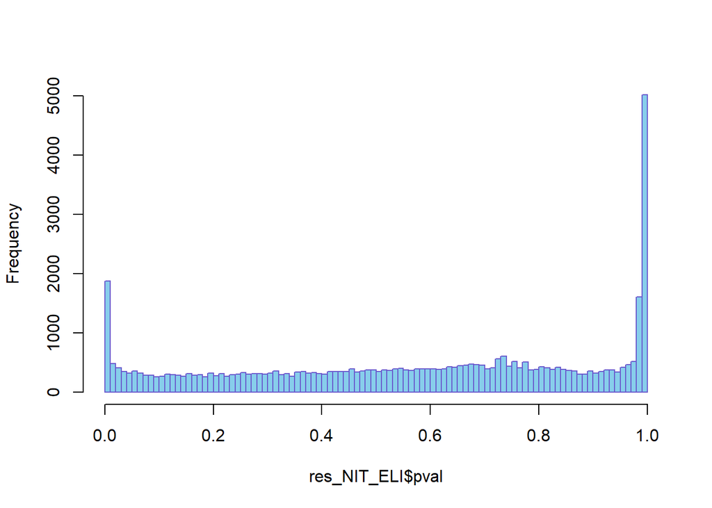

```r
hist(res_NIT_ELI$pval, breaks=100, col="skyblue", border="slateblue", main="")
```

```r
resSig_NIT_ELI = res_NIT_ELI[ res$pval < 0.1, ]
head( resSig_NIT_ELI [ order(resSig_NIT_ELI $pval), ] )
```

```
##                    id   baseMean baseMeanA   baseMeanB foldChange
## 6725  ENSG00000244116  703.58684  7.729016  1399.44466  181.06376
## 3379  ENSG00000143297 1544.82412 12.861630  3076.78661  239.22214
## 52473 ENSG00000211685  520.19139  3.468544  1036.91424  298.94801
## 6717  ENSG00000239951 7346.88428 62.215193 14631.55337  235.17653
## 39134 ENSG00000211937  582.17571  5.637157  1158.71427  205.54941
## 42266 ENSG00000156886   32.53528  1.593986    63.47657   39.82254
##       log2FoldChange         pval         padj
## 6725        7.500354 3.324239e-14 1.461468e-09
## 3379        7.902207 8.504557e-12 1.869472e-07
## 52473       8.223751 3.558902e-10 3.911590e-06
## 6717        7.877600 5.874913e-10 5.165693e-06
## 39134       7.683341 1.289525e-09 9.448781e-06
## 42266       5.315513 1.600153e-09 9.481559e-06
```

## Anotacions

### NIT-SFI

```r
if (!requireNamespace("BiocManager", quietly = TRUE))
    install.packages("BiocManager")

BiocManager::install("org.Hs.eg.db")
BiocManager::install("clusterProfiler")
BiocManager::install("pathview")
BiocManager::install("AnnotationHub")
BiocManager::install("ensembldb")
BiocManager::install("tidyverse")
library(org.Hs.eg.db)
library(DOSE)
library(pathview)
library(clusterProfiler)
library(AnnotationHub)
library(ensembldb)
library(tidyverse)
```

```r
library("AnnotationDbi")
library("org.Hs.eg.db")

resSig$symbol <- mapIds(org.Hs.eg.db,
                     keys = resSig$id,
                     column = "SYMBOL",
                     keytype = "ENSEMBL",
                     multiVals = "first")
resSig$entrez <- mapIds(org.Hs.eg.db,
                     keys = resSig$id,
                     column = "ENTREZID",
                     keytype = "ENSEMBL",
                     multiVals = "first")
resOrdered <- resSig[order(resSig$padj),]
head(resOrdered)
```

```
##                   id    baseMean   baseMeanA   baseMeanB foldChange
## 6725 ENSG00000244116   54.773917    7.729016  101.818817 13.1735811
## 10   ENSG00000237683  641.399299  885.573951  397.224646  0.4485505
## 12   ENSG00000239906    9.984204   13.495751    6.472658  0.4796071
## 161  ENSG00000224387    8.548463   12.182460    4.914467  0.4034051
## 162  ENSG00000229393    9.126995   12.928336    5.325655  0.4119366
## 256  ENSG00000049246 2403.334510 1434.325526 3372.343493  2.3511702
##      log2FoldChange         pval      padj symbol entrez
## 6725       3.719576 4.458933e-06 0.1963001     NA     NA
## 10        -1.156658 4.532037e-03 1.0000000     NA     NA
## 12        -1.060075 3.586046e-02 1.0000000     NA     NA
## 161       -1.309699 6.102902e-02 1.0000000     NA     NA
## 162       -1.279506 7.947056e-02 1.0000000     NA     NA
## 256        1.233379 4.576707e-03 1.0000000   PER3   8863
```